# ap3650_nyc_crime_data_visualization

Anita

March 13, 2018

```r
library(data.table)
library(vcdExtra)
library(extracat)
library(ggplot2)
library(dplyr)
library(tidyverse)
library(lubridate)
library(RColorBrewer)



## Copied from rj2168.rmd for uniform read and variable names

var_names <- c("Id", "DateStart", "TimeStart", "DateEnd", "TimeEnd", "DateReport", "ClassCode", "OffenseDesc",
               "IntClassCode", "IntOffenseDesc", "AtptCptdStatus", "Level", "Jurisdiction", "Boro", "Pct", "LocOfOccr",
               "PremDesc", "ParkName", "HousingDevName", "XCoord", "YCoord", "Lat", "Long", "Lat_Long")

crime_df <- fread("NYPD_Complaint_Data_Historic.csv",na.strings="", col.names = var_names, stringsAsFactors = TRUE)
```

[output not shown]

```r
crime_df%>%mutate_if(is.character,funs(factor(.)))->crime_df
```

## Data Manipulations

```r
#Convert dates and times to correct format

#New Variable Names
crime_df$DateStart  <- as.Date(crime_df$DateStart, format='%m/%d/%Y')
crime_df$DateEnd    <- as.Date(crime_df$DateEnd, format='%m/%d/%Y')
crime_df$DateReport <- as.Date(crime_df$DateReport, format='%m/%d/%Y')

crime_df$TimeStart <- as.POSIXct(crime_df$TimeStart, format='%H:%M:%S')
crime_df$TimeEnd   <- as.POSIXct(crime_df$TimeEnd, format='%H:%M:%S')

#Generate violent crime dataframe
#filter for violent crime
violent_crime_df <- crime_df %>% filter(OffenseDesc == "ASSAULT 3 & RELATED OFFENSES" |
                                          OffenseDesc == "FELONY ASSAULT" |
                                          OffenseDesc == "MURDER & NON-NEGL. MANSLAUGHTER" |
                                          OffenseDesc == "RAPE" |
                                          OffenseDesc == "ROBBERY" |
                                          IntOffenseDesc == "AGGRAVATED SEXUAL ASBUSE" |
                                          IntOffenseDesc == "ASSAULT 2,1,UNCLASSIFIED" |
                                          IntOffenseDesc == "ASSAULT 3" |
                                          IntOffenseDesc == "RAPE 1" |
                                          IntOffenseDesc == "ROBBERY,OPEN AREA UNCLASSIFIED" |
                                          IntOffenseDesc == "SEXUAL ABUSE" |
                                          IntOffenseDesc == "SEXUAL ABUSE 3,2")
#Generate dangerous drugs dataframe
drugs_crime_df <- crime_df %>% filter(OffenseDesc == "DANGEROUS DRUGS")
```

## Warm-up Plot :-) Bar Chart

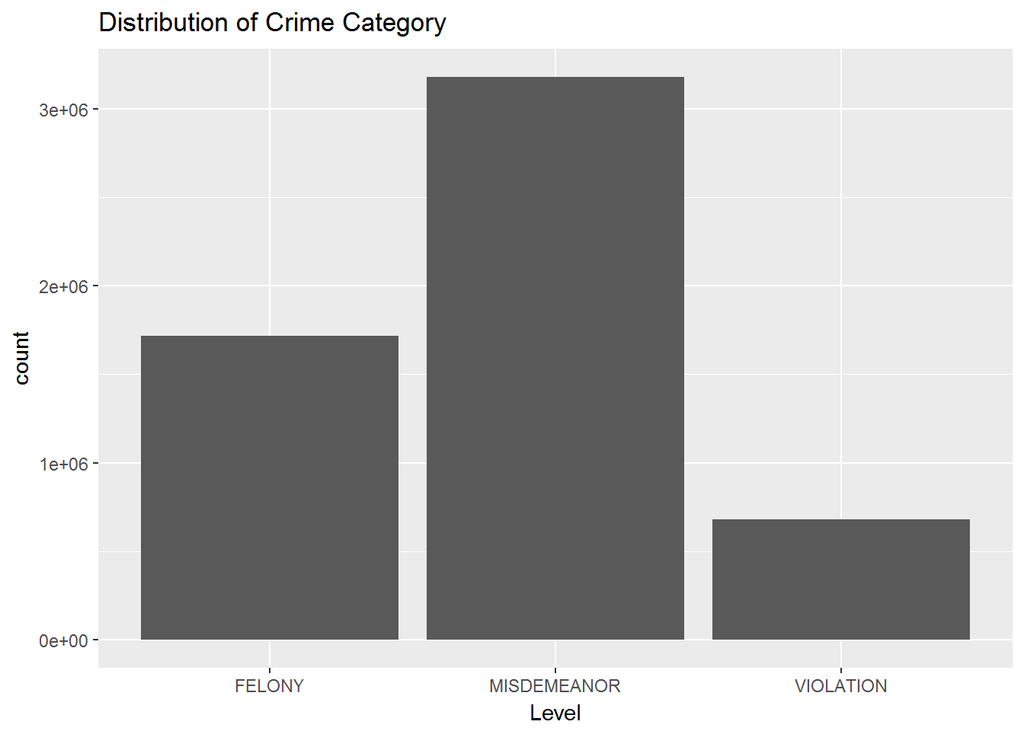

```r
  ggplot(crime_df,aes(Level)) +
    geom_bar() +
    ggtitle("Distribution of Crime Category")
```

** Observation **  
1) Crime Rate of Misdemeanor > Felony > Violation

## Type of Offense VS Place of Offense

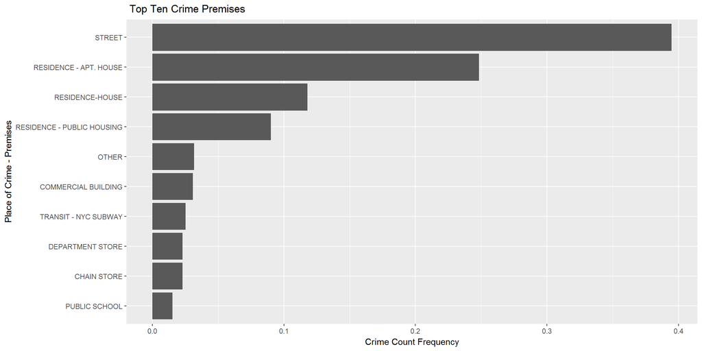

```r
  crime_place <- crime_df %>%
                 filter(!is.na(PremDesc),Level !="") %>%
                 group_by(PremDesc) %>%
                 summarize(count=n()) %>%
                 top_n(n=10, wt=count) %>%
                 mutate(rel_freq = count/sum(count))


  ggplot(crime_place, aes(fct_reorder(PremDesc, rel_freq), rel_freq)) +
    geom_bar(stat="identity") +
    coord_flip() +
    ylab("Crime Count Frequency") +
    xlab("Place of Crime - Premises") +
    ggtitle(" Top Ten Crime Premises")
```

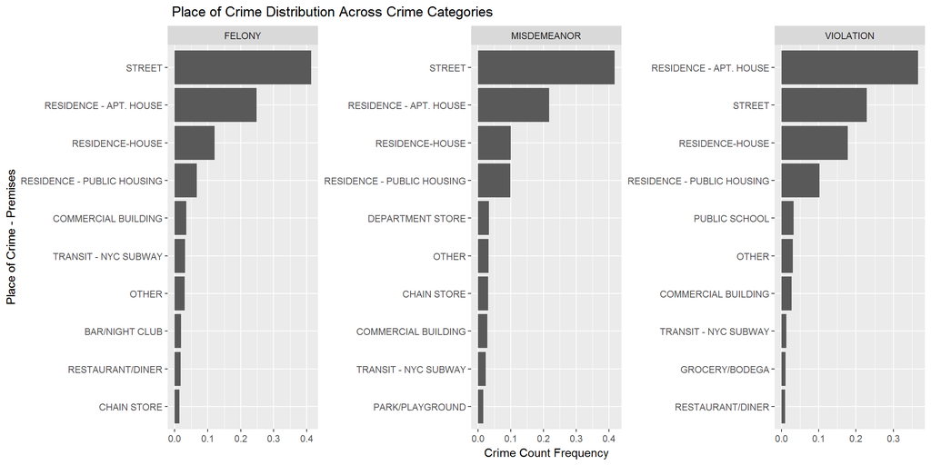

```r
  crime_place_2 <- crime_df %>%
                 filter(!is.na(PremDesc),Level !="") %>%
                 group_by(Level,PremDesc) %>%
                 summarize(count=n()) %>%
                 top_n(n=10, wt=count) %>%
                 mutate(rel_freq = count/sum(count)) %>%
                 ungroup() %>%
                 arrange(Level, rel_freq) %>%
                 unite("PremLevel", PremDesc, rel_freq, sep = "_", remove = FALSE) %>%
                 data.frame() %>%
                 mutate(PremLevel = factor(PremLevel, levels = PremLevel))

  ggplot(crime_place_2, aes(PremLevel, rel_freq)) +
    geom_bar(stat="identity") +
    facet_wrap(~Level, scales="free") +
    coord_flip() +
    ylab("Crime Count Frequency") +
    xlab("Place of Crime - Premises") +
    scale_x_discrete(breaks=crime_place_2$PremLevel,labels=crime_place_2$PremDesc) +
    ggtitle(" Place of Crime Distribution Across Crime Categories")
```

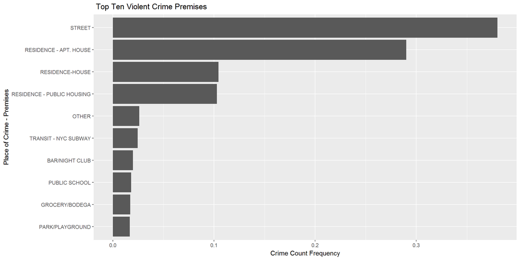

```r
violent_crime_place <- violent_crime_df %>%
  filter(!is.na(PremDesc),Level !="") %>%
  group_by(PremDesc) %>%
  summarize(count=n()) %>%
  top_n(n=10, wt=count) %>%
  mutate(rel_freq = count/sum(count))

ggplot(violent_crime_place, aes(fct_reorder(PremDesc, rel_freq), rel_freq)) +
  geom_bar(stat="identity") +
  coord_flip() +
  ylab("Crime Count Frequency") +
  xlab("Place of Crime - Premises") +
  ggtitle(" Top Ten Violent Crime Premises")
```

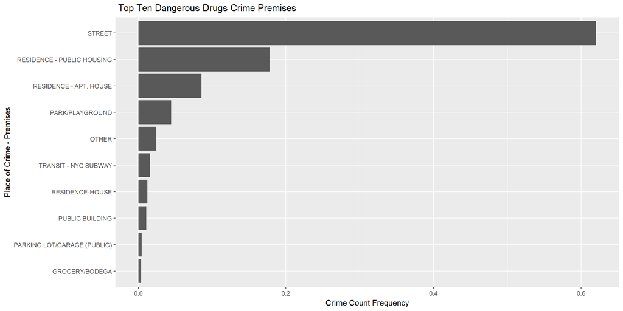

```r
drugs_crime_place <- drugs_crime_df %>%
  filter(!is.na(PremDesc),Level !="") %>%
  group_by(PremDesc) %>%
  summarize(count=n()) %>%
  top_n(n=10, wt=count) %>%
  mutate(rel_freq = count/sum(count))

ggplot(drugs_crime_place, aes(fct_reorder(PremDesc, rel_freq), rel_freq)) +
  geom_bar(stat="identity") +
  coord_flip() +
  ylab("Crime Count Frequency") +
  xlab("Place of Crime - Premises") +
  ggtitle(" Top Ten Dangerous Drugs Crime Premises")
```

**Observations**  
The first plot shows the overall top 10 Locations of Crimes in different Locations in NYC. It is observed that about 40% of the total Crimes are reported on the “Street”. The next 3 top locations reported are Residence-Apt House, Residence-House and Residence - Public Housing. However if we consider all these groups of Residence as one category, they cumulatively add up to more than 45% of the total crimes reported. In short, we can fairly assume that around 85% of crimes reported in NYC are either on the “Streets” or “Residence” Premises.

Commercial Buildings, Transit-NYC Subway, Department Store, Chain Store and Public School individually rank around 2 to 2.5% of the total Crimes Reported.

The second plot shows the Place of Crime Distribution across different Crime Categories. It is observed that for Felony and Misdemeanor, the top places of Crimes are similar. For violations, however the crimes reported in Residence-Apt House is more than those on street. Also, some of the other places of Crime which figure under violations for example Public School, Grocery etc, suggest those of traffic violations.

– Old inference below, remove later —-

1. This graph is messed up in order, i cant get the order right for “violation” category < Done >
2. Shows top locations for crime under different categories
3. Top 3 locations are almost same for call categories, more violations in Apt-Residence than Street.
4. Also observed violations could be parking / traffic violations, typical locations include Public school, Diners/Restaurants, grocery etc

## Top Crime Categories

The classification of crimes reported in NYC is based on two main factors.  
1) The level or the seriousness of the crime, which are Violation, Misdemeanor, Felony  
2) The other classification is based on the category of the crime. At the time of this report data, there are broadly 70 different types of Offense Catgories. Each of these offense categories are further divided into internal offense categories. Based on the severity of the internal offense category, the offense category can either be a violation or misdemeanor or felony. For Example, Offense Category “Dangerous Drugs can either be a Felony(Internal offense Category -”Marijuana Sale“) or a Misdemeanor( Internal Offense Category ->”Marijuana Possession“)

The following plots make an attempt to find out the answers for the following questions:  
1) What are the top 15 Offense Categories ?  
2) Are the top offense Categories similar for all the boroughs ?  
3) Are there any trends over time for the top offense categories ?

## To find Top 15 Crime Categories

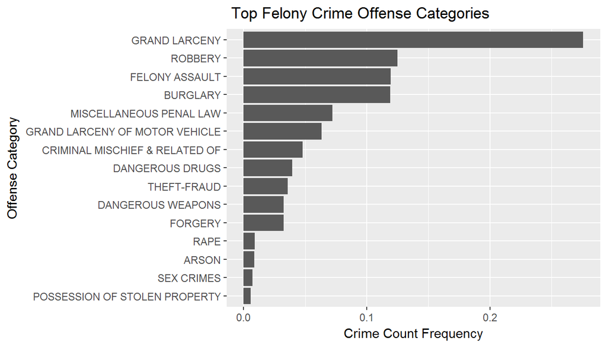

```r
crime_top_felony <- crime_df %>%
  filter(OffenseDesc!="" & Level=="FELONY") %>%
  group_by(OffenseDesc) %>%
  summarize(count=n()) %>%
  mutate(rel_freq = count/sum(count)) %>%
  top_n(n=15, wt=count)

ggplot(crime_top_felony, aes(reorder(OffenseDesc,rel_freq), rel_freq)) +
  geom_col() +
  coord_flip() +
  xlab("Offense Category") +
  ylab("Crime Count Frequency") +
  ggtitle(" Top Felony Crime Offense Categories")
```

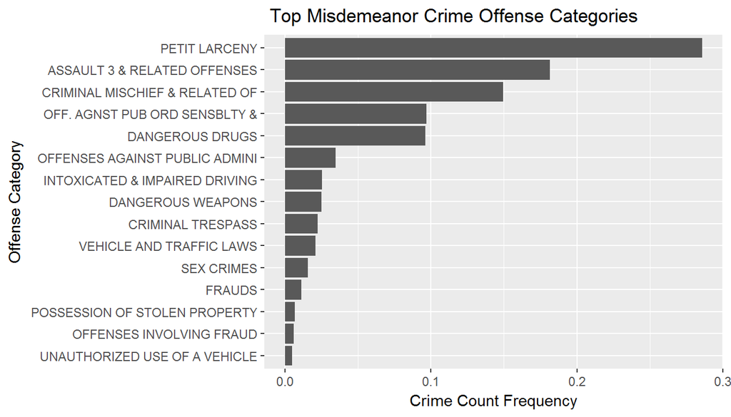

```r
crime_top_misd <- crime_df %>%
  filter(OffenseDesc!="" & Level=="MISDEMEANOR") %>%
  group_by(OffenseDesc) %>%
  summarize(count=n()) %>%
  mutate(rel_freq = count/sum(count)) %>%
  top_n(n=15, wt=count)

ggplot(crime_top_misd, aes(reorder(OffenseDesc,rel_freq), rel_freq)) +
  geom_col() +
  coord_flip() +
  xlab("Offense Category") +
  ylab("Crime Count Frequency") +
  ggtitle(" Top Misdemeanor Crime Offense Categories")
```

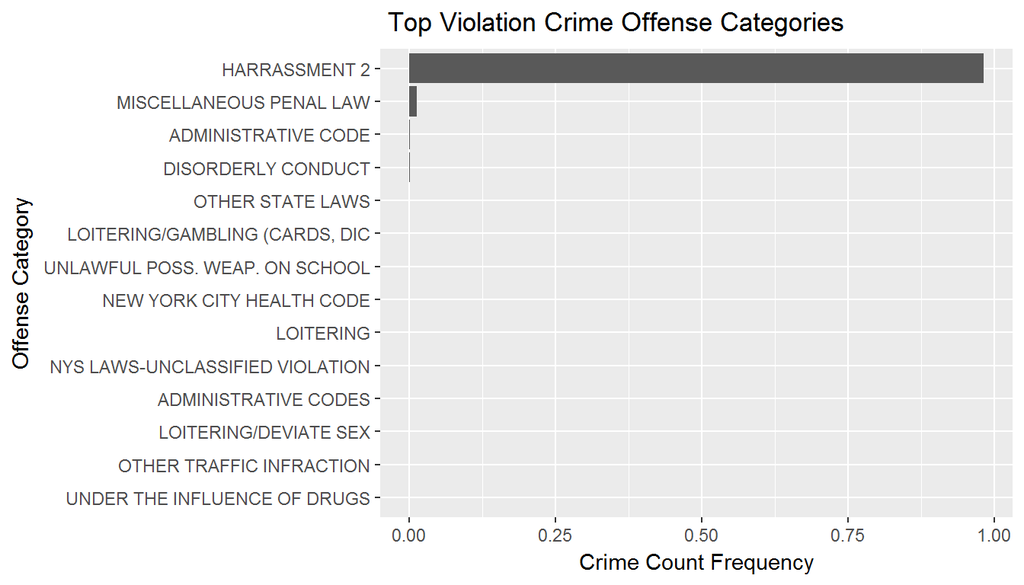

```r
crime_top_violation <- crime_df %>%
  filter(OffenseDesc!="" & Level=="VIOLATION") %>%
  group_by(OffenseDesc) %>%
  summarize(count=n()) %>%
  mutate(rel_freq = count/sum(count)) %>%
  top_n(n=15, wt=count)

ggplot(crime_top_violation, aes(reorder(OffenseDesc,rel_freq), rel_freq)) +
  geom_col() +
  coord_flip() +
  xlab("Offense Category") +
  ylab("Crime Count Frequency") +
  ggtitle(" Top Violation Crime Offense Categories")
```

** old Inference below, remove later**  
1) The top crime categories are Petit Larceny, Harrasment , Assualt, Criminal Mischief, Grand Larceny and Dangerous Drugs  
2) Do we need to find some distribution for these again ??  
3) What is miscellaneous Penal LAw ?

## Boro Vs Top Crime Categories

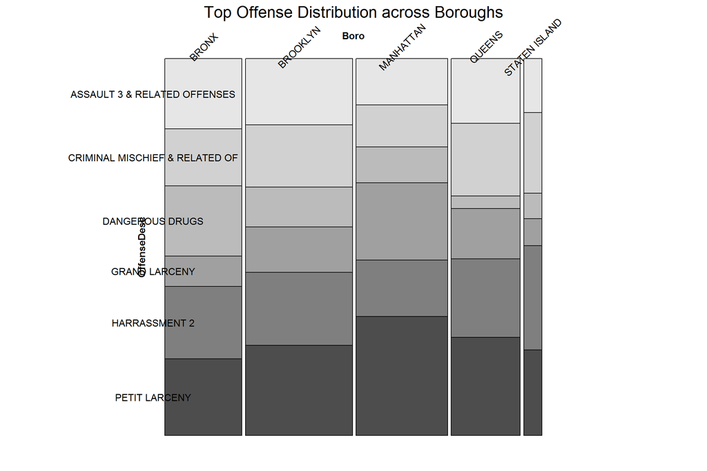

```r
  top_ofns   <- c("PETIT LARCENY", "HARRASSMENT 2", "CRIMINAL MISCHIEF & RELATED OF", "ASSAULT 3 & RELATED OFFENSES", "GRAND LARCENY", "DANGEROUS DRUGS")

  crime_sort <- crime_df %>%
                  filter(Boro != "") %>%
                  filter(OffenseDesc %in% top_ofns) %>%
                  group_by(Boro,OffenseDesc) %>%
                  summarize(Freq=n()) %>%
                  mutate(rel_freq = Freq/sum(Freq))

  crime_sort$OffenseDesc <- factor(crime_sort$OffenseDesc)


  ## I tried changing the code, but I like the above , as it compares borough with top 6 categories
  #crime_sort_1 <- crime_df %>%
  #                filter(Boro != "", OffenseDesc != "") %>%
  #                group_by(Boro,OffenseDesc) %>%
  #                summarize(Freq=n())  %>%
  #                ungroup() %>%
  #                group_by(Boro) %>%
  #                top_n(n=6, wt=Freq)
  #

  #doubledecker(OffenseDesc~Boro, data=crime_sort, gp = gpar(fill = c("grey90", "red")))
  mosaic(OffenseDesc~Boro, main ="Top Offense Distribution across Boroughs", direction=c("v"), labeling=labeling_border(rot_labels=c(45,0,0, 0)), crime_sort)
```

In the above mosaic plot it is easier to compare the top offense distribution within each borough, however to compare acorss borouhs, the stacked bar charts as below would be more useful.

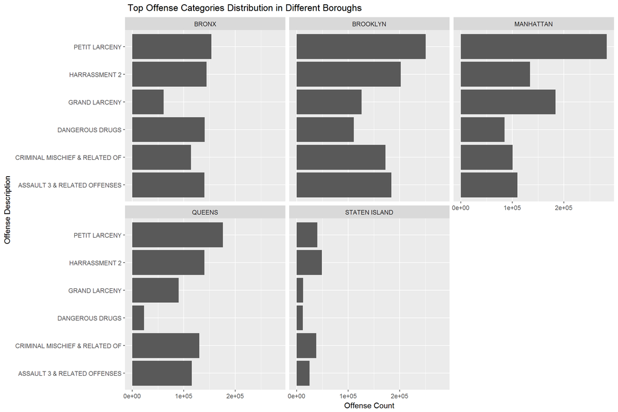

```r
  #doubledecker(TOP_OFFENSE~Boro, data=crime_sort)
  ggplot(crime_sort, aes(OffenseDesc,Freq)) +
    geom_col() +
    ylab("Offense Count") +
    xlab("Offense Description") +
    facet_wrap(~ Boro) +
    coord_flip() +
    ggtitle(" Top Offense Categories Distribution in Different Boroughs")
```

** Inference from Mosaic Plot **  
1) How the Top crimes are distributed across Boroughs ?  
2) Drugs are more in Bronx compared to Queens  
3) Manhattan tops for Petit Larceny and Grand Larceny  
4) In staten Island, Harrasment tops among other crimes in staten island  
5) From the stacked bar graphs, it shows some comparisions easier. For example in mosaic it is difficult to compare areas of distribution when widths of bars are not same. However Here it clearly shows comparisons among boroughs for each crime as well within boroughs for different crimes

The above plot shows distribution of top offense categories in different boroughs. But we were curious to know if these were really the top offense category for each borough or if there stood out other offsenses which were more seen in one borough but not in the other. To analyse if top offenses varied for each borough, we plotted the following plot. We also included the crime levels to know the severity of these top offense categories.

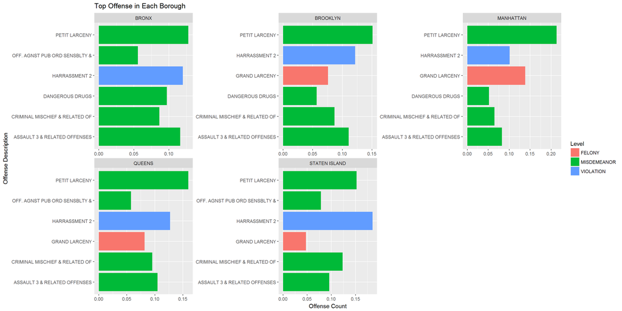

```r
crime_boro_top <- crime_df %>%
                  filter(Boro !="", OffenseDesc !="" , Level != "") %>%
                  group_by(Boro, Level, OffenseDesc) %>%
                  summarize(count=n()) %>%
                  ungroup() %>%
                  group_by(Boro) %>%
                  mutate(rel_freq = count/sum(count)) %>%
                  top_n(n=6, wt=rel_freq)

ggplot(crime_boro_top, aes(OffenseDesc, rel_freq, fill= Level)) +
  geom_col() +
  coord_flip() +
  facet_wrap(~Boro, scales="free") +
  xlab("Offense Description") +
  ylab("Offense Count") +
  ggtitle("Top Offense in Each Borough")
```

Using the above plot, we observe that the top offenses for each borough vary little differently. For Manhattan and Brooklyn the top offense distribution is similar to that of NYC taken as whole. None of the top offenses exceeed more than 20% of total crimes for each borough except Petite Larceny in Manhattan. The other top offense featured in Bronx, Queens and Staten Island is Offense Against Pub Ord Sensibility.

Next, it would be interesting to analyse the trend of top offenses in each borough over the years.

** (Old inference for old graph) The above plot shows something surprising, the categories are not standard, need to research more. For example, dangerous drugs is under Felony as well as Misdemeanor!! **

## Time Trend of Top Offense Category

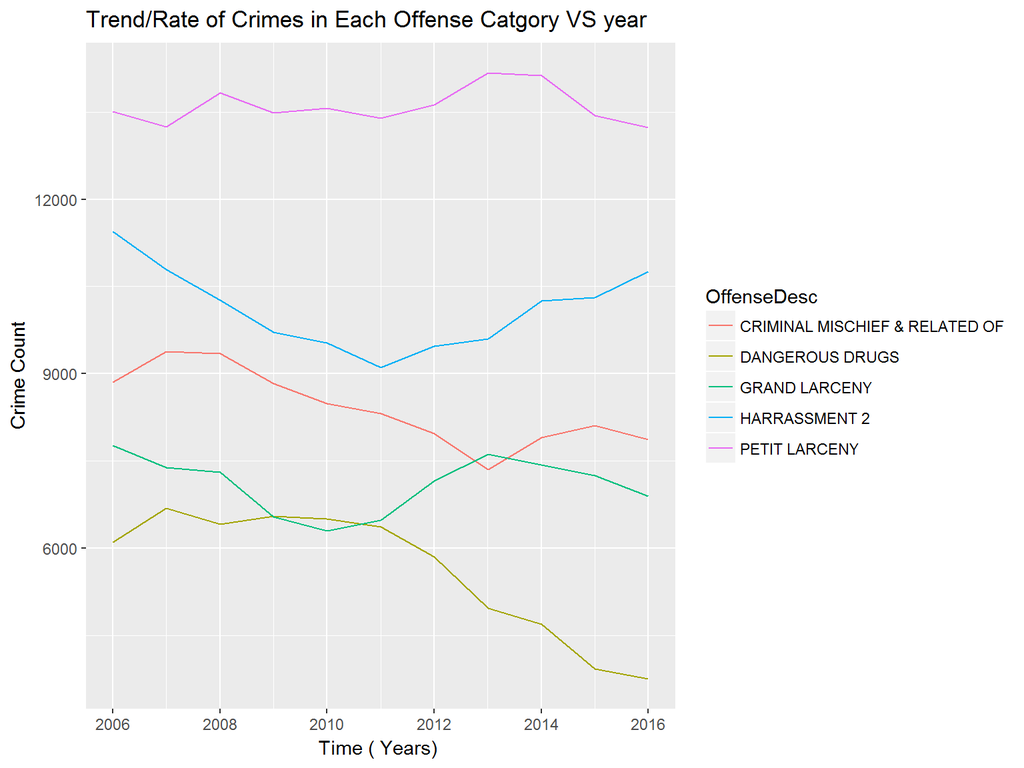

```r
    top_ofns   <- c("PETIT LARCENY", "HARRASSMENT 2", "CRIMINAL MISCHIEF & RELATED OF", "ASSAUALT 3 & RELATED OFFENSES", "GRAND LARCENY", "DANGEROUS DRUGS")
    crime_time_top_ofns <- crime_df %>%
                            filter(year(DateStart)>2005, (OffenseDesc == top_ofns)) %>%
                            group_by(Date=floor_date(DateStart, "year"),OffenseDesc) %>%
                            summarize(count=n())

    crime_time_top_ofns <- crime_time_top_ofns %>%
                            group_by(OffenseDesc) %>%
                            mutate(rel_count = count*100/count[1])

    ggplot(crime_time_top_ofns, aes(Date,count, color = OffenseDesc))+
          geom_line() +
          xlab("Time ( Years) ") +
          ylab("Crime Count") +
          ggtitle("Trend/Rate of Crimes in Each Offense Catgory VS year")
```

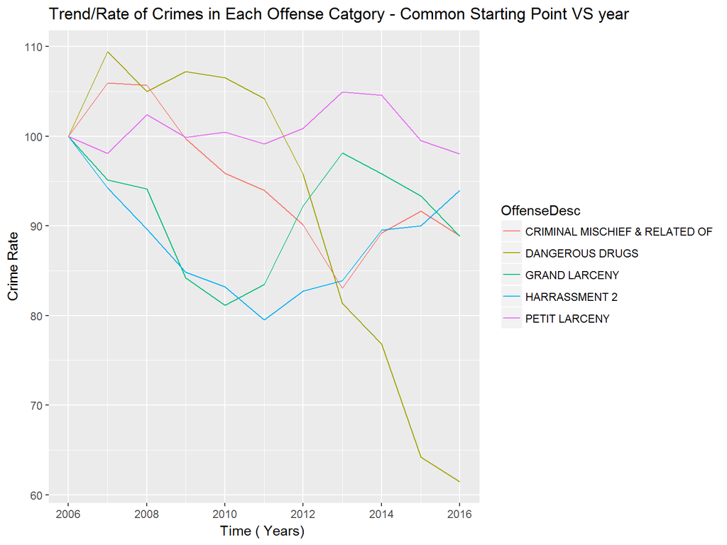

```r
    ggplot(crime_time_top_ofns, aes(Date,rel_count, color = OffenseDesc))+
          geom_line() +
          xlab("Time ( Years) ") +
          ylab("Crime Rate") +
          ggtitle("Trend/Rate of Crimes in Each Offense Catgory - Common Starting Point VS year")
```

**Inference**  
1) The first graph captures the trend of crimes over the years 2006-2016.  
2) The ranks of top crimes have not changed from 2006 to 2016, except in 2013, we see a dip in number of crimes of category “criminal mischief” , similar dip is observed in “Grand Larceny” in 2010 3) To compare the trends of crime by fixing them to a common starting point, we observe that the “dangerous Drugs” category has dipped down drasticaly when compared to other crimes.  
4) Harrasment has shown an increase in the last five years.  
5) There is slight increase in Criminal Mischief during the period 2013-2015 6) There is a sudden increase in Grand Larceny and Petite Larceny from 2011 to 2013, more than other crimes

## Crime PD top

Since the offense Categories are classified at very broad level, it would make more sense to perform analysis on Internal Offense Categories.

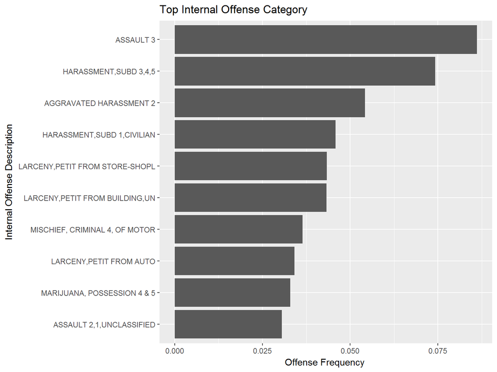

```r
    crime_pd_top <- crime_df %>%
                      filter(IntOffenseDesc != "" && !is.na(IntOffenseDesc)  && (Boro != "")) %>%
                      group_by(IntOffenseDesc) %>%
                      summarize(count = n()) %>%
                      mutate(rel_freq = count/sum(count)) %>%
                      top_n(n=10 ,wt=rel_freq)


  ggplot(crime_pd_top, aes(reorder(IntOffenseDesc,rel_freq), rel_freq)) +
    geom_col() +
    coord_flip()+
    ggtitle("Top Internal Offense Category") +
    xlab("Internal Offense Description") +
    ylab("Offense Frequency ")
```

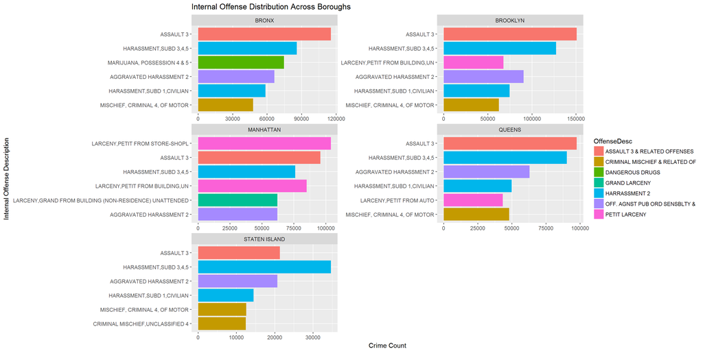

```r
    crime_pd_top_all_boro <- crime_df %>%
                      filter(!is.na(Boro)) %>%
                      filter(IntOffenseDesc != "" && !is.na(IntOffenseDesc) && OffenseDesc != "" && Boro != ""  ) %>%
                      group_by(Boro,OffenseDesc, IntOffenseDesc) %>%
                      summarize(count = n()) %>%
                      ungroup() %>%
                      group_by(Boro) %>%
                      top_n(n=6, wt=count) %>%
                      arrange(Boro, desc(count))

  ggplot(crime_pd_top_all_boro, aes(reorder(IntOffenseDesc,count),count, fill=OffenseDesc)) +
    geom_col() +
    coord_flip() +
    facet_wrap(~Boro, scales="free" , ncol=2) +
    ggtitle("Internal Offense Distribution Across Boroughs") +
    xlab("Internal Offense Description")  +
    ylab("Crime Count")
```

**Inference**  
Interesting to observe the internal classification of top crimes levels  
1) These plots are just to analyse the sub categories of Crime/ Offense. There are total 410 Internal Offense Categories  
2) Petite Larceny is generally from stores and building  
3) Different levels of Harassment take the top ranks 2-4  
4) Crimes involving Drugs are usually Possession of Marijuana  
5) Not sure if you want to use borough comparisions again

*total classification of overall crimes (pd_desc) -> 409*

The NewYork City Crime Report Data has one of it is variables as “Parks” which provides details of names of parks in which crimes have occurred. We were curious to know if there are any specific types of crimes which are common in NYC parks or if they are random in nature. We also tried to explore if crime types in different borough parks were same or different.

## Crimes in parks Analysis

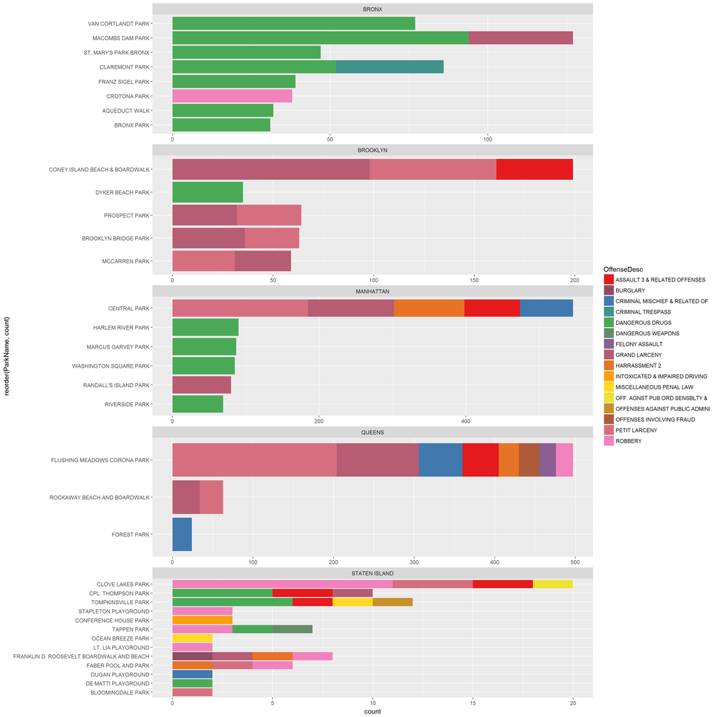

```r
  crime_parks <- crime_df %>%
                  filter(Boro!="",ParkName!="",Level!="") %>%
                  group_by(Boro,ParkName,Level) %>%
                  summarize(count=n())

  #crime_parks <- crime_parks %>%
  #                arrange(desc(count))

 crime_pk <- crime_parks %>%
                 group_by(Boro) %>%
                 top_n(n=10, wt=count)

  crime_parks_1 <- crime_df %>%
                  filter(Boro!="",ParkName!="",OffenseDesc!="") %>%
                  group_by(Boro,ParkName,OffenseDesc) %>%
                  summarize(count=n())

 crime_pk_1 <- crime_parks_1 %>%
                 group_by(Boro) %>%
                 top_n(n=10, wt=count) %>%
                 arrange(Boro,desc(count))

  getPalette = colorRampPalette(brewer.pal(18, "Set1"))

  #ggplot(crime_pk_1 ,aes(reorder(ParkName,count), count, fill=OffenseDesc)) +
  #  geom_col() +
  #  facet_wrap(~Boro, ncol=1, scales="free_y") +
  #  scale_fill_manual(values = getPalette(18)) +
  #  coord_flip()

  ggplot(crime_pk_1 ,aes(reorder(ParkName,count),  count, fill=OffenseDesc)) +
    geom_col() +
    facet_wrap(~Boro, ncol=1, scales="free") +
    scale_fill_manual(values = getPalette(18)) +
    coord_flip()
```

** Inference **  
1) Most parks in Bronx have crimes related to Drugs  
2) Drugs does not figure among the top crimes in Cental park in Manhatan, where as other parks of Manhatan have Drugs as one of their top category  
3) For the parks in Queens, Drugs does not figure as top crimes in any of the parks

“Attempted Crime” is another variable in NYC Crime Data Report, which we wanted to explore. We wanted to analyse if there was any simmilarity in crime counts between Attempted Crime and Completed Crime.

## Atempted Crime vs Type of Crime

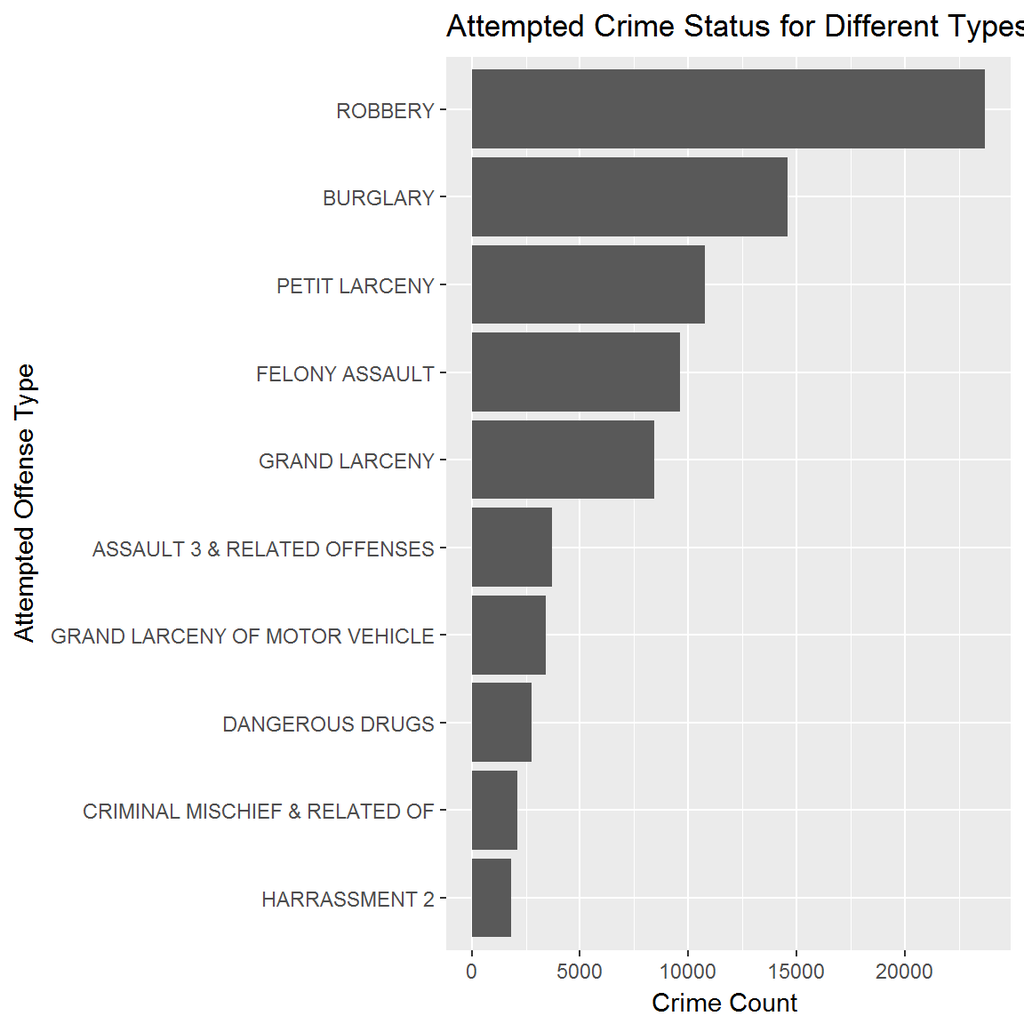

```r
  crime_stat <- crime_df %>%
                  filter(AtptCptdStatus == "ATTEMPTED" & OffenseDesc !="") %>%
                  group_by(OffenseDesc) %>%
                  summarize(count=n()) %>%
                  top_n(n=10, wt=count)

  ggplot(crime_stat,aes(reorder(OffenseDesc,count),count)) +
      geom_col() +
      coord_flip() +
      xlab("Attempted Offense Type") +
      ylab("Crime Count ") +
      ggtitle("Attempted Crime Status for Different Types of crime")
```

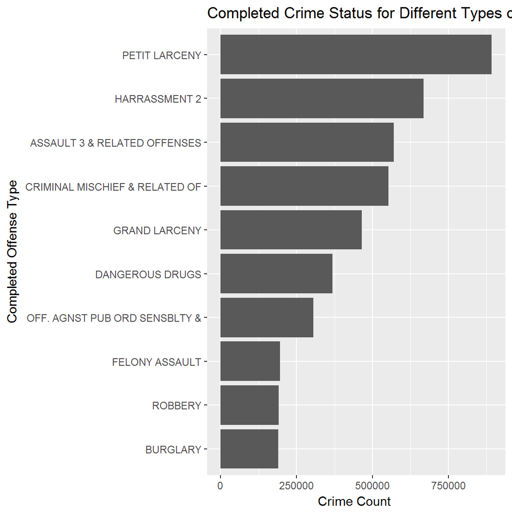

```r
  crime_stat_cmtd <- crime_df %>%
                  filter(AtptCptdStatus == "COMPLETED" & OffenseDesc !="") %>%
                  group_by(OffenseDesc) %>%
                  summarize(count=n()) %>%
                  top_n(n=10, wt=count)

  ggplot(crime_stat_cmtd,aes(reorder(OffenseDesc,count),count)) +
      geom_col() +
      coord_flip() +
      xlab("Completed Offense Type") +
      ylab("Crime Count ") +
      ggtitle("Completed Crime Status for Different Types of crime")
```

** Inference **  
1) Total number of offense categories under attempted category is around 55  
2) Among top crimes in attempted catgeory is Robbery, Burglar, petit larceny, felony assault, grand lacerny 3) Are these categories the top offense categories too ?  
4) For completed categories, the top categories are Petit Larceny, Harrasment 2, Assualt 3, criminal mischief, Grand larceny

## Attempted Crime Trend

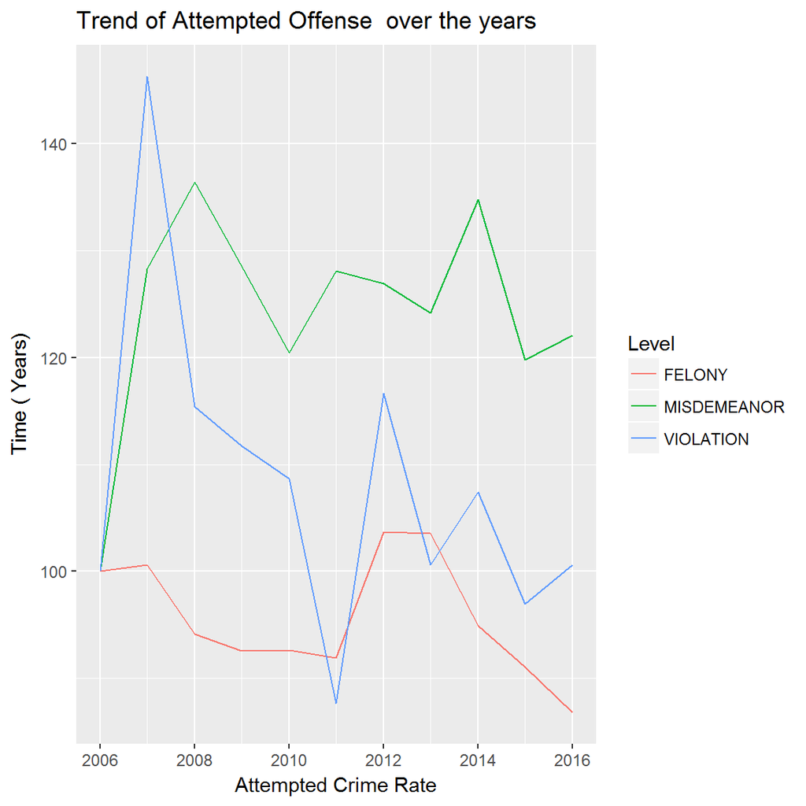

```r
  crime_stat <- crime_df %>%
                  filter(AtptCptdStatus=="ATTEMPTED" & year(DateStart)>2005 & Level != "") %>%
                  group_by(Date=floor_date(DateStart,"year"),Level) %>%
                  summarize(count=n()) %>%
                  ungroup() %>%
                  group_by(Level) %>%
                  mutate(rel_count = count*100/count[1])

  ggplot(crime_stat, aes(Date,rel_count,color=Level)) +
    geom_line() +
    ggtitle("Trend of Attempted Offense  over the years") +
    xlab("Attempted Crime Rate") +
    ylab("Time ( Years)")
```

**Inference**  
1) Over the years, the rate for attempted crime category for Felony is reducing much drastically than violation or misdemeanor  
## Month and Time and Type of Crime

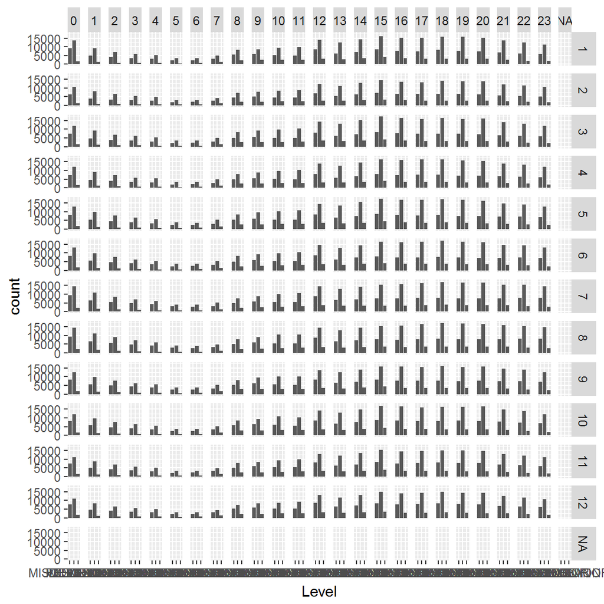

```r
  #crime_df <- crime_df %>% drop_na()
  ggplot(crime_df, aes(Level)) +
  geom_bar() +
  #facet_wrap(~month(DateStart))
  #facet_wrap(~hour(TimeStart))
  facet_grid(month(DateStart)~hour(TimeStart))
```

** Inference **  
1) Shows less crime during 5 am to 7 am , peak crime 3 pm to 8 pm  
2) The peak and low hourly variances is consistent across months

** Below Are Time Series , which we can choose if needed apart from other plots **

## Time Series - Trend of Crime Rate

[figure not shown]

```r
    crime_time <- crime_df %>%
                    filter(year(DateStart)>2005) %>%
                    group_by(Date=floor_date(DateStart, "year"),Level) %>%
                    summarize(count=n())

    ggplot(crime_time, aes(Date,count, color=Level))+
          geom_line() +
          ggtitle("Trend/Rate of Crimes in Each Category Across year")
```

[figure not shown]

```r
    crime_time <- crime_df %>%
                    filter(year(DateStart)>2005) %>%
                    group_by(Date=floor_date(DateStart, "month"),Level) %>%
                    summarize(count=n())

    ggplot(crime_time, aes(Date,count, color=Level))+
          geom_line() +
          ggtitle("Trend/Rate of Crimes in Each Category Across year - sampled month-wise")
```

[figure not shown]

```r
    crime_boro_m <- crime_df %>%
                      filter(year(DateStart)> 2005 & Boro != "") %>%
                      group_by(Date=floor_date(DateStart,"month"),Boro) %>%
                      summarize(count=n())

    ggplot(crime_boro_m,aes(Date,count,color=Boro)) +
      geom_line() +
      ggtitle("Crime Trend over Years comparing Boroughs")
```

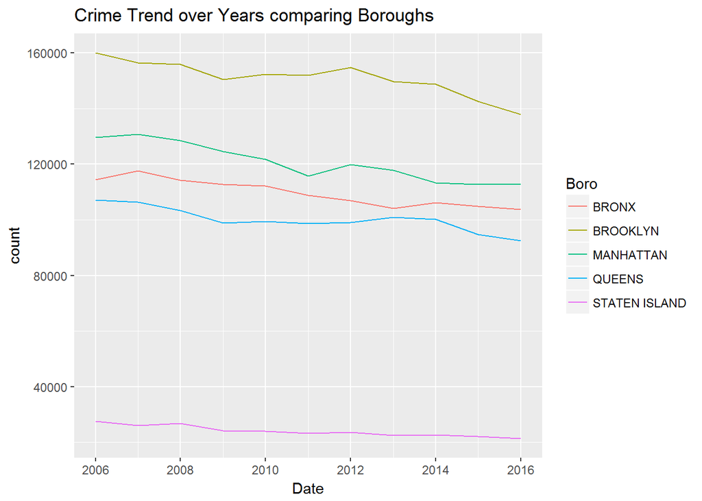

```r
    crime_boro_y <- crime_df %>%
                      filter(year(DateStart)> 2005 & Boro != "") %>%
                      group_by(Date=floor_date(DateStart,"year"),Boro) %>%
                      summarize(count=n()) %>%
                      ungroup() %>%
                      group_by(Boro) %>%
                      mutate(rel_count = count*100/count[1])

    ggplot(crime_boro_y,aes(Date,count,color=Boro)) +
      geom_line() +
      ggtitle("Crime Trend over Years comparing Boroughs")
```

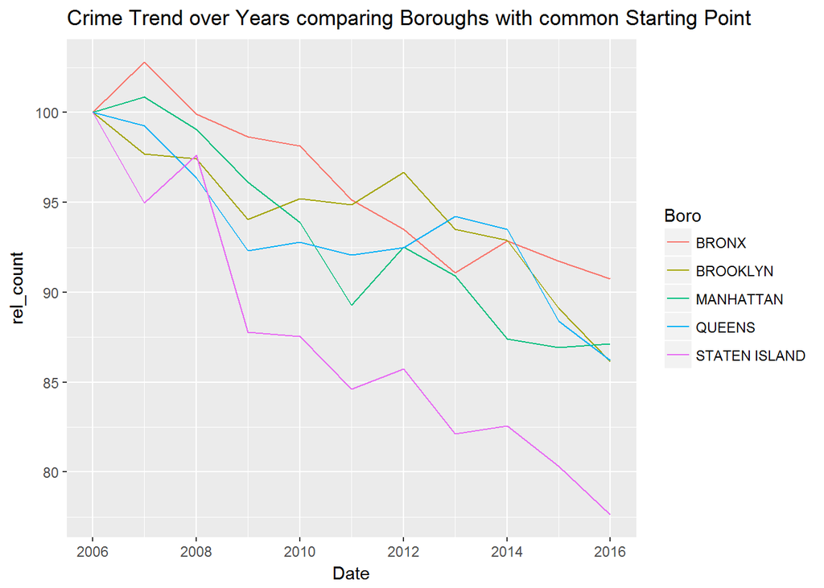

```r
    ggplot(crime_boro_y,aes(Date,rel_count,color=Boro)) +
      geom_line() +
      ggtitle("Crime Trend over Years comparing Boroughs with common Starting Point")
```

## length of Crime Vs Type of Crime

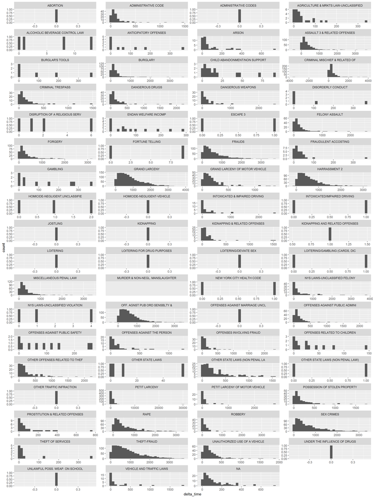

```r
  #crime_time <- crime_df %>%  drop_na() %>%
  crime_time <- crime_df %>%
                    filter(year(DateStart)>2005) %>%
                    mutate(delta_time = as.numeric(DateEnd - DateStart)) %>%
                    group_by(OffenseDesc, delta_time) %>%
                    summarize(count=n())

  ggplot(crime_time,aes(delta_time)) +
    geom_histogram(na.rm=TRUE) +
    facet_wrap(~OffenseDesc, ncol = 4, scales="free")
```

1. There are some cases where there might be typo on “To Date” especially year might be typo  
2. Observed larceny( grand and petite have lot of cases )  
3. There are blank OFfense category 4. I dont like this analysis anymore

## trial on ggmap

```r
  #library(ggmap)

  #NYC <- get_map(location = "new york city",  color = "bw", zoom = 15, source = "google")
  #ggmap(NYC)
  #
  #ggplot()+geom_point(data = crime_df, aes(x = Longitude, y = Latitude ,colour = factor(Level)))
```